# Chapter5

Salla Veijonaho

26 11 2020

# 23.11.2020

# **Exercise 5: Clustering and classification**

**Description of the analysed data**

The data set used in these analysis consists of 8 variables (n = 155) and all the variables in the data are continuous. The data combines several indicators from most countries in the world. The variables measure phenomena related to health & knowledge and gender empowerment

Read more about the data from [here](http://hdr.undp.org/en/content/human-development-index-hdi)

##### **Here’s a little glossary to help understand the short terms used in tables:**

**GNI** = Gross National Income per capita

**Life.Exp** = Life expectancy at birth

**Edu.Exp** = Expected years of schooling

**Mat.Mor** = Maternal mortality ratio

**Ado.Birth** = Adolescent birth rate

**Parli.F** = Percetange of female representatives in parliament

**Edu2.FM** = Proportion of females/ males with at least secondary education

**Labo.FM** = Proportion of females/ males in the labour force

##### **Find bellow the descriptions of variables in the data set**

```r
#Open packages
library(psych)
library(tidyverse)
library(corrplot)
library(GGally)
library(ggplot2)

#Read the data

human <- read.table("http://s3.amazonaws.com/assets.datacamp.com/production/course_2218/datasets/human2.txt", sep=",", header=TRUE)

#Checking the data
str(human)
```

[output not shown]

```r
describe(human)
```

```
##           vars   n     mean       sd   median  trimmed      mad    min
## Edu2.FM      1 155     0.85     0.24     0.94     0.87     0.12   0.17
## Labo.FM      2 155     0.71     0.20     0.75     0.73     0.17   0.19
## Edu.Exp      3 155    13.18     2.84    13.50    13.24     2.97   5.40
## Life.Exp     4 155    71.65     8.33    74.20    72.40     7.56  49.00
## GNI          5 155 17627.90 18543.85 12040.00 14552.58 13337.47 581.00
## Mat.Mor      6 155   149.08   211.79    49.00   104.70    63.75   1.00
## Ado.Birth    7 155    47.16    41.11    33.60    41.62    35.73   0.60
## Parli.F      8 155    20.91    11.49    19.30    20.32    11.42   0.00
##                 max     range  skew kurtosis      se
## Edu2.FM        1.50      1.33 -0.76     0.55    0.02
## Labo.FM        1.04      0.85 -0.87     0.05    0.02
## Edu.Exp       20.20     14.80 -0.20    -0.34    0.23
## Life.Exp      83.50     34.50 -0.76    -0.15    0.67
## GNI       123124.00 122543.00  2.14     6.83 1489.48
## Mat.Mor     1100.00   1099.00  2.03     4.16   17.01
## Ado.Birth    204.80    204.20  1.13     0.89    3.30
## Parli.F       57.50     57.50  0.55    -0.10    0.92
```

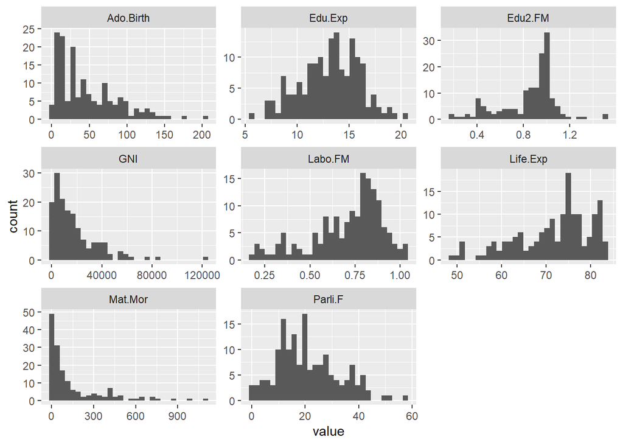

```r
gather(human) %>% ggplot(aes(value)) + facet_wrap("key", scales = "free") + geom_histogram()
```

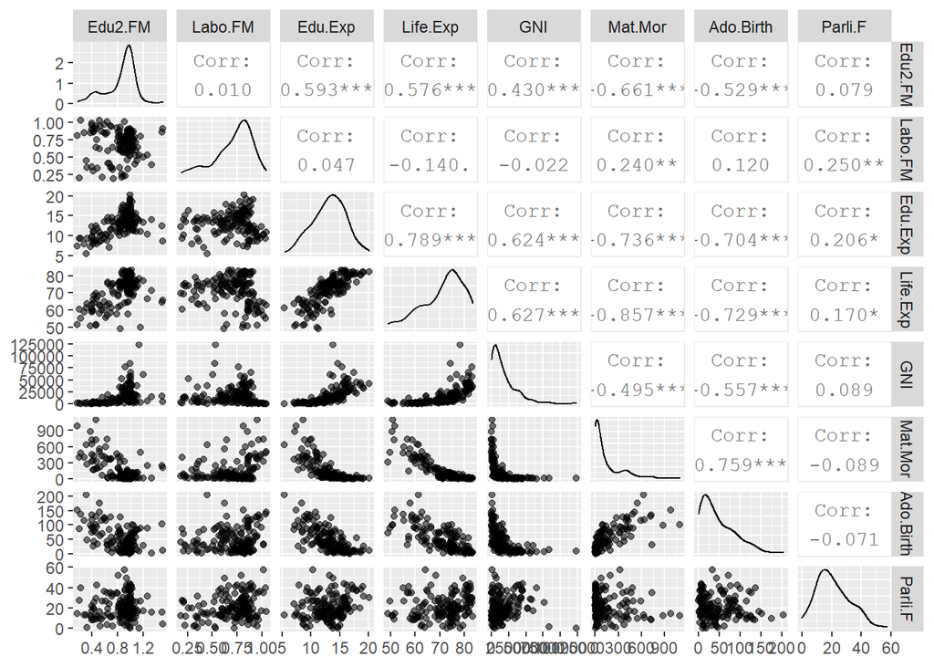

```r
p <- ggpairs(human, mapping = aes(alpha = 0.3), lower = list(combo = wrap("facethist", bins = 20)))
p
```

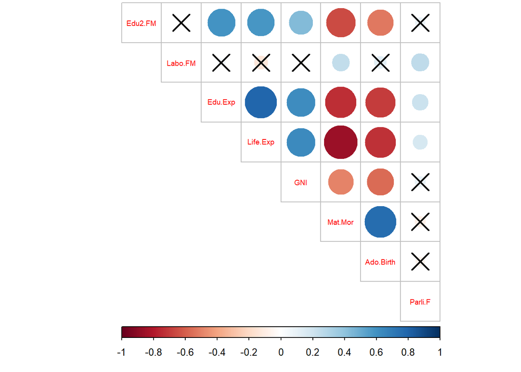

```r
cor_matrix<-cor(human) %>% round(digits = 2)
pvalues <-cor.mtest(human, conf.level = .95)
corrplot(cor_matrix, method= "circle", type="upper", cl.pos="b", tl.pos="d", tl.cex = 0.6, number.cex=0.5,p.mat=pvalues$p, sig.level=0.05)
```

When we look at the descriptive table and histograms above, we can see that there are couple variables that are highly skewed. Adolescent birth rate and Maternal mortality ratio seem to be quite low in most of the countries. Also GNI (Gross National Income per capita) is under 40 000 in the majority of the countries.

Also, when we look at the ggpairs output and correlation matrix, we can see that there are high positive correlation between Adolescent birth rate and Maternal mortality ratio. Life expectancy at birth correlates negatively with both maternal morality ration and adolescent birth rate. There are also high negative correlation between Expected years of schooling and Adolescent birth rate. On the line with other strong correlations, there are also strong positive correlation between Expected years of schooling and Life expectancy at birth.